# Standard HR Data Quality Control Report (Q-Check)

Ifeanyi Edochie

2025-12-16

# Standard HR Quality Control Analytics Report

## Overview

This report presents a comprehensive quality control assessment of the harmonized payroll data comprising the **Contract**, **Personnel**, and **Establishment** modules according to the standard harmonization dictionary (`govhr::harmonization_dict()`). All diagnostic tables are generated automatically using the `compute_qualitycontrol()` function, which evaluates the aforementioned harmonized modules.

## Diagnostic Sections

### Data Basics

This section provides a high-level profile of the harmonized payroll data and summarizes the structure of the three core modules—**Contract**, **Personnel**, and **Establishment**—before detailed diagnostics are introduced.

#### Module Dimensions

The harmonized dataset includes the following components:

### Module Dimensions Summary

Module

Observations

Variables

Contract

344,920

23

Personnel

336,905

9

Establishment

65

9

#### Temporal and Cross-Sectional Coverage

This section visualizes data coverage across time periods, highlighting potential spikes or gaps in observations that may indicate data quality issues or structural changes.

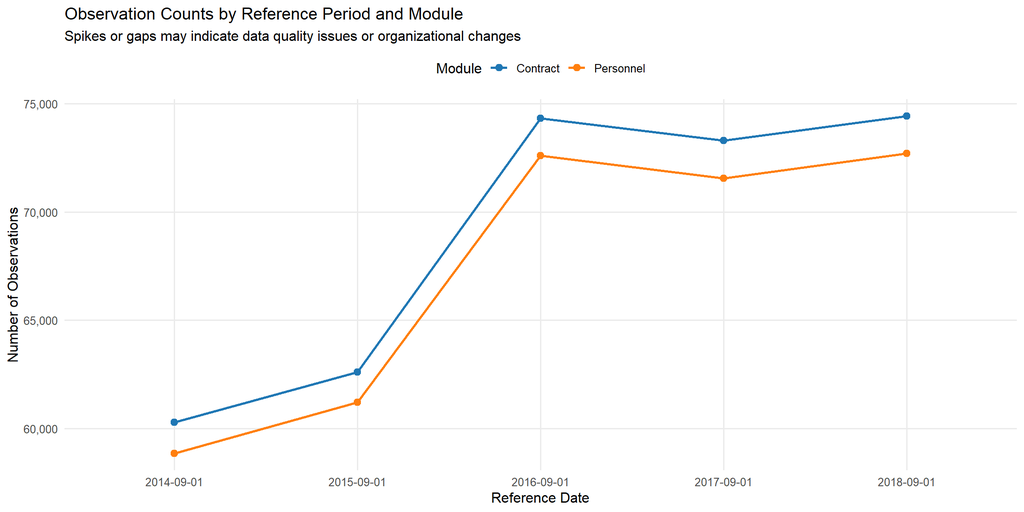

#### Variable Structure & Dictionary Conformity

This section compares the variables present in each harmonized module against the standard harmonization dictionary. It identifies:

- **Missing variables**: Expected by the dictionary but absent from the data
- **Extra variables**: Present in the data but not in the dictionary

### Structure Diagnostics by Module

Module

Missing Variables<sup>1</sup>

Extra Variables<sup>2</sup>

Contract

worker_id, org_id

Establishment

est_name_en

est_name_english, ref_date, est_type

Personnel

birth_date, country_code

est_id, est_name_native, birth_day

<sup>1</sup> Red badges indicate variables expected by the dictionary but missing from the data

<sup>2</sup> Orange badges indicate variables present in the data but not in the dictionary

#### Primary Key Integrity

This section validates that the Contract module’s primary keys (`contract_id`, `personnel_id`, `ref_date`) uniquely identify each record without duplication.

### Primary Key Uniqueness Check

Check

Status

Primary Keys Unique

✓ PASS

Number of Duplicate Groups

0

#### Cross-Module Orphan Checks

This section identifies orphaned records—IDs referenced in the Contract module that don’t exist in the Personnel or Establishment modules.

### Orphan Records Summary

Check

Missing Count

Status

Personnel IDs in Contract missing from Personnel module

0

✓ PASS

Establishment IDs in Contract missing from Establishment module

825

⚠ WARNING

### Sample Orphaned Establishment IDs (First 25)

Orphaned Establishment IDs

SECRETARIA DE ESTADO DA SEGURANCA PUBLICA-302100-2016

DEPARTAMENTO DE ESTRADAS DE RODAGEM-404799-2014

DEPARTAMENTO DE ESTRADAS DE RODAGEM-404799-2015

SECRETARIA DE ESTADO DA MULHER CIDADANIA DIREITOS HUMANOS-320106-2017

SECRETARIA DE ESTADO DA SEGURANCA PUBLICA-302100-2015

SECRETARIA DE ESTADO DA SEGURANCA PUBLICA-302100-2017

SECRETARIA DE ESTADO DA SEGURANCA PUBLICA-302100-2014

SECRETARIA DE ESTADO DA MULHER CIDADANIA DIREITOS HUMANOS-320106-2015

SECRETARIA DE ESTADO DA MULHER CIDADANIA DIREITOS HUMANOS-320106-2016

SECRETARIA DE ESTADO DA MULHER CIDADANIA DIREITOS HUMANOS-320106-2014

DEPARTAMENTO DE ESTRADAS DE RODAGEM-404799-2016

SECRETARIA DE ESTADO DA SEGURANCA PUBLICA-302100-2018

COMPANHIA ALAGOANA DE RECURSOS HUMANOS E PATRIMONIAIS-445000-2014

COMPANHIA ALAGOANA DE RECURSOS HUMANOS E PATRIMONIAIS-445000-2015

COMPANHIA ALAGOANA DE RECURSOS HUMANOS E PATRIMONIAIS-445000-2016

INSTITUTO DE METROLOGIA E QUALIDADE DE ALAGOAS-452537-2016

DEPARTAMENTO ESTADUAL DE TRANSITO DE ALAGOAS-405101-2015

INSTITUTO DE METROLOGIA E QUALIDADE DE ALAGOAS-452537-2015

INSTITUTO DE METROLOGIA E QUALIDADE DE ALAGOAS-452537-2018

INSTITUTO DE METROLOGIA E QUALIDADE DE ALAGOAS-452537-2017

DEPARTAMENTO ESTADUAL DE TRANSITO DE ALAGOAS-405101-2014

SECRETARIA DE ESTADO DA SAUDE-302000-2018

DEPARTAMENTO DE ESTRADAS DE RODAGEM-405501-2015

SEC DE ESTADO DA AGRICULTURA PECUARIA PESCA E AQUICULTURA-301400-2015

Total orphaned establishment IDs: 825

### Missingness Report

This section examines patterns of missing data across the Contract, Personnel, and Establishment modules.  
Understanding missingness is essential for data quality control because it highlights variables that may require cleaning, imputation, or further validation by the data provider.

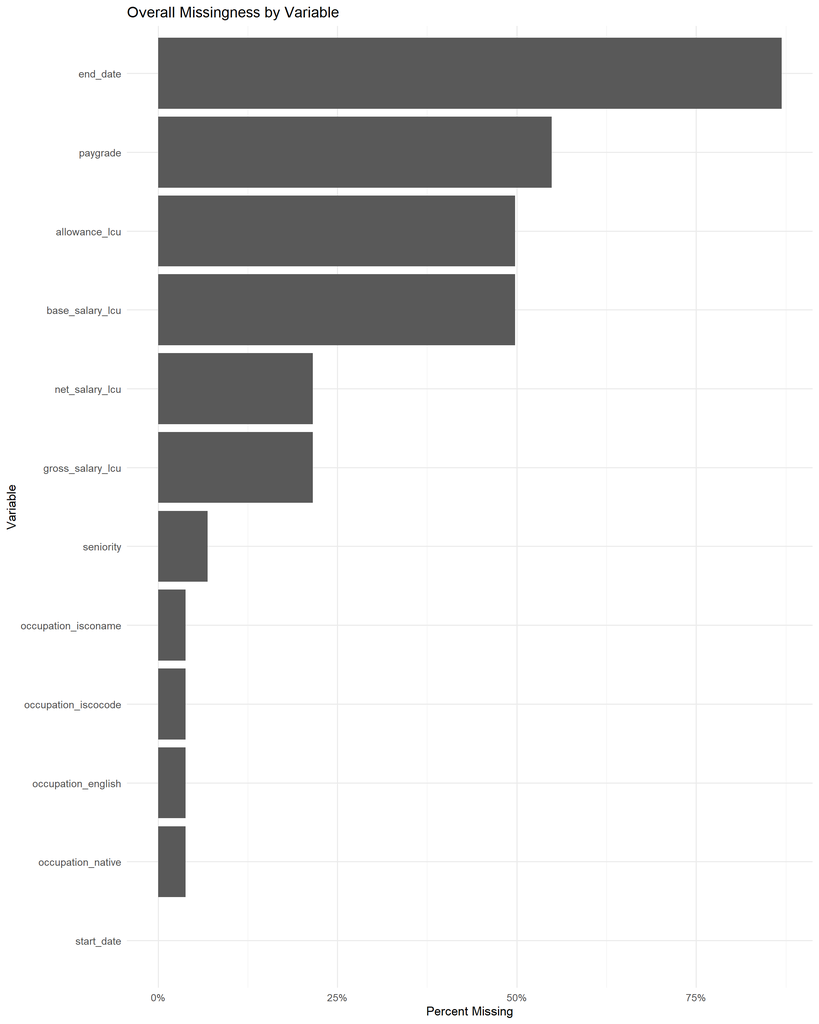

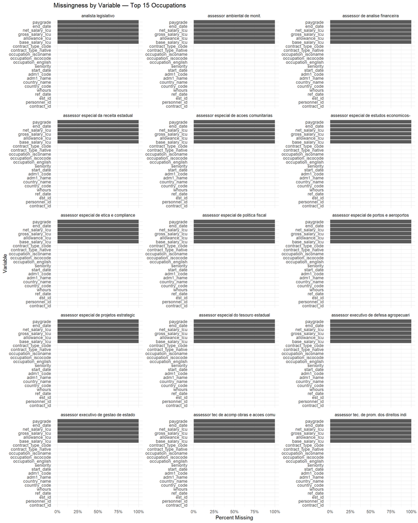

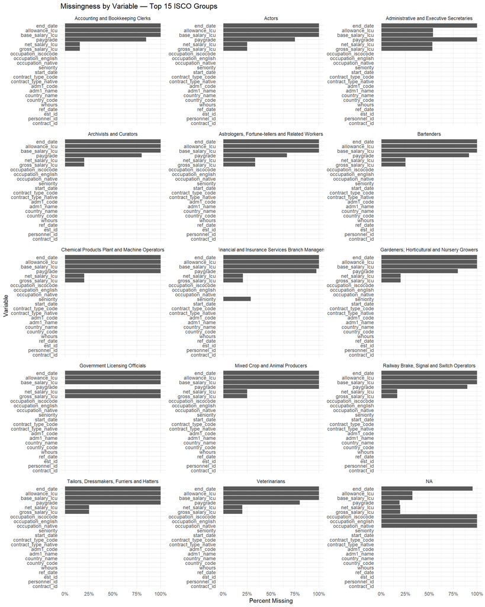

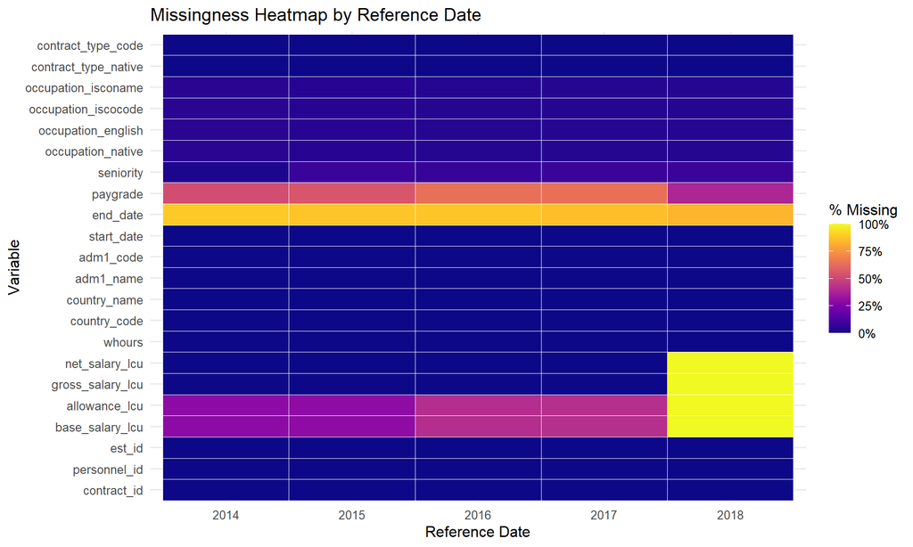

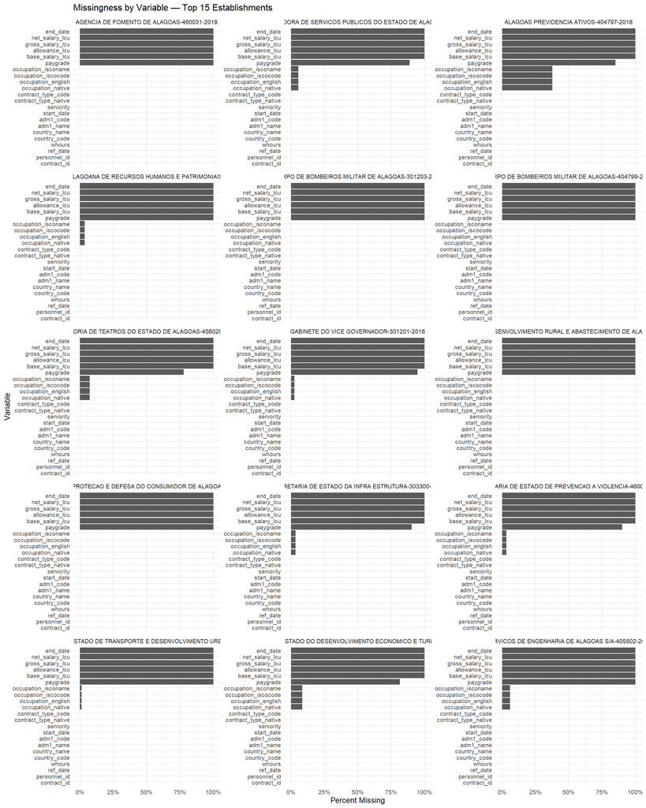

### Volatility Analysis

This section evaluates temporal stability across key HR metrics—salary aggregates, wagebill, staff counts, and contract counts. Volatility is measured using rolling coefficients of variation (CV) or percent changes to identify establishments with unstable patterns over time.

High volatility may indicate:

- Data quality issues (inconsistent reporting, missing periods)
- Legitimate organizational changes (restructuring, budget changes)
- Seasonal patterns or policy changes

The heatmaps below show volatility metrics for the top 50 contracts with the highest average salary volatility, allowing identification of patterns that warrant further investigation.

#### Contract Volatility in Salary

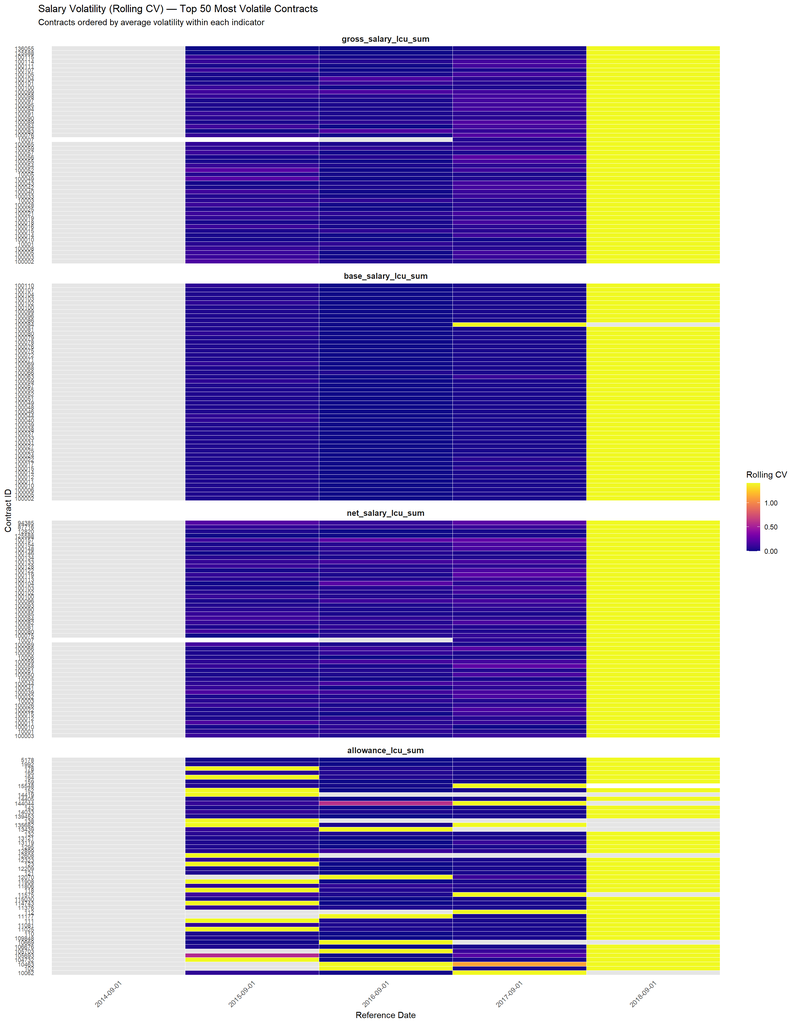

#### Contract Count Volatility

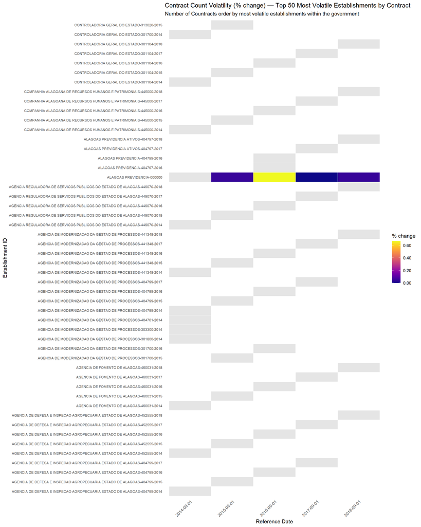

#### Contract Level Volatility in Hours Worked

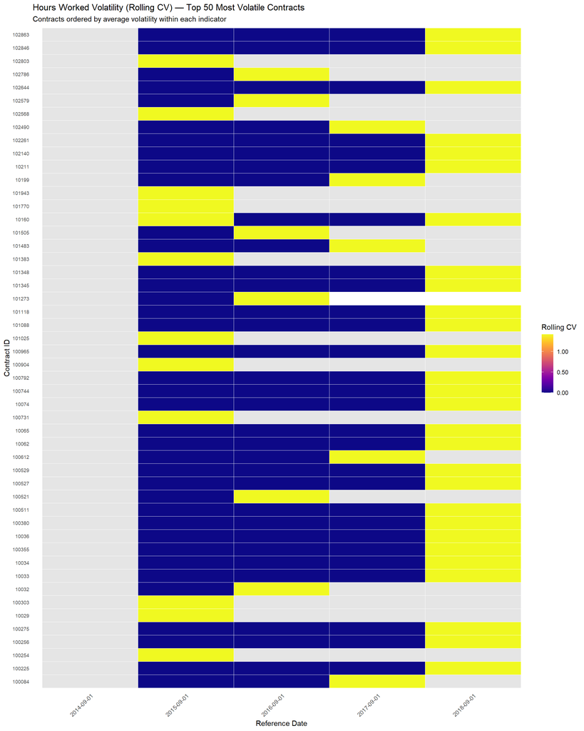